# Evidencia 1, Análisis Inicial

Marcela Hernández Ramírez A01658023

2023-04-25

# Evidencia 1 | Análisis inicial

## Parte 1

### 1. ¿Cuál es la situación actual de COVID-19 a nivel mundial, en México, en tu estado de origen y en tu municipio, alcaldía o colonia?

La situación de COVID-19 a nivel mundial conforme al último dato registrado el 03/10/2023 de la Universidad de John Hopkins es de 676.609.955 casos. En México, según la página oficial del Consejo Nacional de Ciencia y Tecnología, hasta el 18/04/2023 se registraron 7.568.585 casos en todo el país. Con relación a ello, en la Ciudad de México se registraron el 03/10/2023 24.975 casos. Respecto a la alcaldía Tlalpan, los últimos datos recopilados el 07/27/2023 en el sitio oficial del Gobierno de México, indica que hubo 159,455 casos positivos. Por lo que, se puede concluir que en el 2023, gracias a las vacunas y a las medidas de prevención, los casos han bajado drásticamente.

### 2. ¿Cuál fue la primera variante del virus que se propagó a todo el mundo?

La primera variante del virus SARS-CoV-2 que se propagó a todo el mundo es la variante original, que se identificó por primera vez en Wuhan, China a finales de 2019. Esta variante original del virus se denominó comúnmente como la cepa “D614G” debido a una mutación específica en la proteína de espiga del virus.

### 3. ¿Cuáles son las otras variantes del virus que existen en otras regiones del mundo?

**Variante Alfa**: Identificada por primera vez en el Reino Unido en septiembre de 2020. Se ha demostrado que es más transmisible y puede ser más mortal.

**Variante Beta** : Identificada por primera vez en Sudáfrica en mayo de 2020. Se ha demostrado que es más transmisible y puede evadir la respuesta inmunitaria en algunos casos.

**Variante Gamma** : Identificada por primera vez en Brasil en diciembre de 2020. Se ha demostrado que es más transmisible y puede ser más resistente a la respuesta inmunitaria en algunos casos.

**Variante Delta** : Identificada por primera vez en India en diciembre de 2020. Se ha demostrado que es más transmisible y puede ser más resistente a la respuesta inmunitaria en algunos casos.

Además de estas variantes, también se identificaron otras en diferentes regiones del mundo, como la variante Epsilon (California), la variante Zeta (Brasil), la variante Eta (Nigeria), entre otras.

### 4. ¿Cómo buscarías información de la variante del virus en tu país?

Al estar haciendo la investigación, me percaté que las páginas del gobierno de México, Universidades Europeas y Estadounidenses, además de la OMS (Organización Mundial de la Salud) tienen datos respecto a como el COVID-19 se ha propagado a lo largo del territorio mexicano desde que llegó por primera vez al país hasta la actualidad. Me basaría en esas fuentes de información, ya que son confiables y primarias.

### 5. Imagina que te encuentras en una situación similar a la de Li Wenliang, médico chino que intentó alertar sobre el brote de coronavirus en su país, pero fue detenido por las autoridades y obligado a retractarse, ¿qué harías en su caso? Selecciona un inciso:

1. Lo reportas al centro de investigación o la universidad.
2. Lo reportas a la prensa.
3. Guardas la información. Elige y justifica tu respuesta.

Yo haría lo que dice el inciso “a”, lo reportaría al centro de investigación o a la universidad, hay tener en cuenta la importancia de la ética médica y el compromiso con la salud pública, por lo que considero que lo más responsable es informar a las autoridades sanitarias competentes para poder tomar medidas preventivas y de control.

## Parte 2

### 1. Obtén las secuencias de las variantes de SARS-CoV-2

```r
library(Biostrings)
library(seqinr)
alpha <- read.fasta("alpha.fasta")

beta <- read.fasta("beta.fasta")

delta <- read.fasta("delta.fasta")

omicron <- read.fasta("omicron.fasta")

variantes <- list(alpha, beta, delta, omicron)
```

### 2. Calcula la longitud de las secuencias de cada variante.

```r
names(variantes)<- c("Alpha","Beta","Delta","Omicron")

longitud <- function(variante)
{
  length(variante[[1]])
}

virus <- lapply(variantes, longitud)
virus
```

```
## $Alpha
## [1] 29801
##
## $Beta
## [1] 29764
##
## $Delta
## [1] 29816
##
## $Omicron
## [1] 29693
```

### 3. %GC de cada variante

```r
codones <- function(cadena)
{
  nucleo <- count(cadena[[1]],1)
  clotidos <- nucleo/length(cadena[[1]])
  clotidos[[2]]+clotidos[[3]]
}
lapply(variantes,codones)
```

```
## $Alpha
## [1] 0.3795846
##
## $Beta
## [1] 0.3765959
##
## $Delta
## [1] 0.3567548
##
## $Omicron
## [1] 0.3656754
```

### 4. Secuencias contrasentido de cada variante y nucleotidos

```r
hebra_inversa<-function(hd){
  hi<-c()
  cont=1
  for(i in length(hd):1){
    hi[cont]<-hd[i]
    cont=cont+1
  }
  return(hi)
}
```

### Alpha

```r
hebra_inversa(variantes$Alpha[[1]])[c(1:5,(length(variantes$Alpha[[1]])-5):length(variantes$Alpha[[1]]))]
```

```
##  [1] "g" "a" "t" "a" "a" "a" "a" "c" "c" "a" "a"
```

### Beta

```r
hebra_inversa(variantes$Beta[[1]])[c(1:5,(length(variantes$Beta[[1]])-5):length(variantes$Beta[[1]]))]
```

```
##  [1] "c" "c" "t" "a" "t" "t" "c" "t" "a" "g" "a"
```

### Delta

```r
hebra_inversa(variantes$Delta[[1]])[c(1:5,(length(variantes$Delta[[1]])-5):length(variantes$Delta[[1]]))]
```

```
##  [1] "c" "g" "a" "t" "a" "c" "c" "a" "a" "c" "c"
```

### Omicron

```r
hebra_inversa(variantes$Omicron[[1]])[c(1:5,(length(variantes$Omicron[[1]])-5):length(variantes$Omicron[[1]]))]
```

```
##  [1] "a" "a" "g" "t" "g" "t" "c" "t" "a" "g" "a"
```

```r
contar <- function(variantes)
  {
    count(variantes[[1]],1)
}
virus <- lapply(variantes,contar)
virus
```

```
## $Alpha
##
##    a    c    g    t
## 8903 5468 5844 9586
##
## $Beta
##
##    a    c    g    t
## 8819 5408 5801 9509
##
## $Delta
##
##    a    c    g    t
## 8315 5148 5489 8879
##
## $Omicron
##
##    a    c    g    t
## 8585 5255 5603 9229
```

### 5. Crea una gráfica donde compares las bases de ADN que componen a cada una de las variantes del virus.

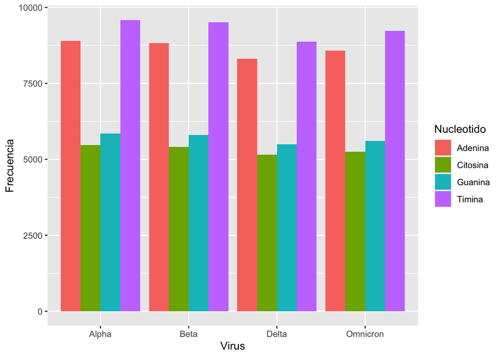

```r
library("ggplot2")
nuc_Alpha <- c(virus[[1]])
nuc_Beta <- c(virus[[2]])
nuc_Delta <- c(virus[[3]])
nuc_Omnicron <- c(virus[[4]])

tabla <- data.frame(Nucleotido = c("Adenina", "Citosina", "Guanina", "Timina", "Adenina", "Citosina", "Guanina", "Timina", "Adenina", "Citosina", "Guanina", "Timina", "Adenina", "Citosina", "Guanina", "Timina"), Virus = c("Alpha", "Alpha", "Alpha", "Alpha", "Beta", "Beta", "Beta", "Beta", "Delta", "Delta", "Delta", "Delta", "Omnicron", "Omnicron", "Omnicron", "Omnicron"), Frecuencia = c(nuc_Alpha, nuc_Beta, nuc_Delta, nuc_Omnicron))

ggplot(tabla, aes(x=Virus, y=Frecuencia, fill=Nucleotido)) + geom_col(position="dodge")
```

### 6. Agrega una interpretación escrita de las gráficas que integras.

| Nucleotido | Virus | Frecuencia |
| --- | --- | --- |
| Adenina | Alpha | 8903 |
| Citosina | Alpha | 5468 |
| Guanina | Alpha | 5844 |
| Timina | Alpha | 9586 |
| Adenina | Beta | 8819 |
| Citosina | Beta | 5408 |
| Guanina | Beta | 5801 |
| Timina | Beta | 9509 |
| Adenina | Delta | 8315 |
| Citosina | Delta | 5148 |
| Guanina | Delta | 5489 |
| Timina | Delta | 8879 |
| Adenina | Omnicron | 8585 |
| Citosina | Omnicron | 5255 |
| Guanina | Omnicron | 5603 |
| Timina | Omnicron | 9229 |

### Para concluir:

Las secuencias variantes del SARS-CoV-2 se pueden obtener de la base de datos del NCBI o de la herramienta de búsqueda de virus del NCBI.

La longitud de las secuencias variantes del SARS-CoV-2 oscila entre aproximadamente 29 000 y 30 000 nucleótidos.

La adenina (A) y la timina (T) son más abundantes que la citosina (C) y la guanina (G) en las secuencias variantes del SARS-CoV-2.

### Referencias:

BBC News. (2021, 15 de febrero). Coronavirus: ¿Qué se sabe de las variantes sudafricana, británica y brasileña? Recuperado el 19 de abril de 2023, de https://www.bbc.com/mundo/noticias-55536492

Centro de Control y Prevención de Enfermedades (CDC). (2021). Clasificaciones de variantes del SARS-CoV-2. Recuperado el 19 de abril de 2023, de https://espanol.cdc.gov/coronavirus/2019-ncov/variants/variant-classifications.html

Centro de Control y Prevención de Enfermedades (CDC). (2021). Variantes del virus que causan COVID-19. Recuperado el 19 de abril de 2023, de https://www.cdc.gov/coronavirus/2019-ncov/variants/index.html

Consejo Nacional de Ciencia y Tecnología (CONACYT). (2023). Plataforma Datos Abiertos COVID-19. Recuperado el 19 de abril de 2023, de https://datos.covid-19.conacyt.mx/#DOView

Johns Hopkins University. (2023). COVID-19 Dashboard by the Center for Systems Science and Engineering (CSSE) at Johns Hopkins University (JHU). Recuperado el 19 de abril de 2023, de https://coronavirus.jhu.edu/map.html

National Center for Biotechnology Information (NCBI). (s.f.). SARS-CoV-2 Data Hub. Recuperado el 19 de abril de 2023, de https://www.ncbi.nlm.nih.gov/activ?lineage=B-1-1-529

Organización Mundial de la Salud (OMS). (2022, 25 de enero). Tracking SARS-CoV-2 variants. Recuperado el 19 de abril de 2023, de https://www.who.int/en/activities/tracking-SARS-CoV-2-variants/